# Worked Challenges: Day 1

RAdelaide 2025

Author

Affiliation

Dr Stevie Pederson

Black Ochre Data Labs  
The Kids Research Institute Australia

Published

July 11, 2025

## Piping Functions

The challenges are:

### Setup

```r
library(tidyverse)
library(palmerpenguins)
theme_set(theme_bw()) # Optional but nice
```

### Challenge 1

```r
penguins |>
  arrange(body_mass_g) |> # Sort by body_mass in increasing order
  slice(1:5) |> # Grab the first 5
  mutate(body_mass_kg = body_mass_g / 1000) # Convert from g to kg
```

```
# A tibble: 5 × 9
  species   island bill_length_mm bill_depth_mm flipper_length_mm body_mass_g
  <fct>     <fct>           <dbl>         <dbl>             <int>       <int>
1 Chinstrap Dream            46.9          16.6               192        2700
2 Adelie    Biscoe           36.5          16.6               181        2850
3 Adelie    Biscoe           36.4          17.1               184        2850
4 Adelie    Biscoe           34.5          18.1               187        2900
5 Adelie    Dream            33.1          16.1               178        2900
# ℹ 3 more variables: sex <fct>, year <int>, body_mass_kg <dbl>
```

### Challenge 2

```r
penguins |>
  dplyr::filter(sex == "male") |> # Subset to male penguins
  summarise(
    mean_bill_length = mean(bill_length_mm), # Summarise
    .by = species # Sorry. I left this out from the questino
  ) |>
  arrange(desc(mean_bill_length))
```

```
# A tibble: 3 × 2
  species   mean_bill_length
  <fct>                <dbl>
1 Chinstrap             51.1
2 Gentoo                49.5
3 Adelie                40.4
```

**Comment**: It looks like I left out the expectation for these to be summarised by species from the question.

### Challenge 3

**Approach 1**

```r
penguins |> count(island, year)
```

```
# A tibble: 9 × 3
  island     year     n
  <fct>     <int> <int>
1 Biscoe     2007    44
2 Biscoe     2008    64
3 Biscoe     2009    60
4 Dream      2007    46
5 Dream      2008    34
6 Dream      2009    44
7 Torgersen  2007    20
8 Torgersen  2008    16
9 Torgersen  2009    16
```

**Comment**: It appears that the answer is already sorted, but you cold add `arrange(island, year)` to ensure that any future modifications to the data were robust to change

**Approach 2**

```r
penguins |>
  summarise(n = n(), .by = c(island, year)) |>
  arrange(island, year)
```

```
# A tibble: 9 × 3
  island     year     n
  <fct>     <int> <int>
1 Biscoe     2007    44
2 Biscoe     2008    64
3 Biscoe     2009    60
4 Dream      2007    46
5 Dream      2008    34
6 Dream      2009    44
7 Torgersen  2007    20
8 Torgersen  2008    16
9 Torgersen  2009    16
```

**Comment**: Under this approach, results do need to be sorted

### Challenge 4

```r
penguins |>
  slice_max(body_mass_g, n = 1, by = c(species, island)) |>
  arrange(desc(body_mass_g))
```

```
# A tibble: 5 × 8
  species   island    bill_length_mm bill_depth_mm flipper_length_mm body_mass_g
  <fct>     <fct>              <dbl>         <dbl>             <int>       <int>
1 Gentoo    Biscoe              49.2          15.2               221        6300
2 Chinstrap Dream               52            20.7               210        4800
3 Adelie    Biscoe              43.2          19                 197        4775
4 Adelie    Torgersen           42.9          17.6               196        4700
5 Adelie    Dream               39.8          19.1               184        4650
# ℹ 2 more variables: sex <fct>, year <int>
```

### Challenge 5

```r
penguins_raw |>
  mutate(
    year = year(`Date Egg`),
    Species = str_extract(Species, "^[:alpha:]+"),
    Sex = str_to_lower(Sex)
  ) |>
  dplyr::select(
    studyName, ends_with("ID"),
    Species, Island, starts_with("Culmen"), starts_with("Flipper"),
    starts_with("Body"), Sex, year
  ) |>
  rename_with(
    \(x) {
      x |>
        str_replace("Culmen", "beak") |>
        str_remove_all("[\\(\\)]") |>
        str_to_lower() |>
        str_replace_all(" ", "_")
    }
  )
```

```
# A tibble: 344 × 10
   studyname individual_id species island    beak_length_mm beak_depth_mm
   <chr>     <chr>         <chr>   <chr>              <dbl>         <dbl>
 1 PAL0708   N1A1          Adelie  Torgersen           39.1          18.7
 2 PAL0708   N1A2          Adelie  Torgersen           39.5          17.4
 3 PAL0708   N2A1          Adelie  Torgersen           40.3          18
 4 PAL0708   N2A2          Adelie  Torgersen           NA            NA
 5 PAL0708   N3A1          Adelie  Torgersen           36.7          19.3
 6 PAL0708   N3A2          Adelie  Torgersen           39.3          20.6
 7 PAL0708   N4A1          Adelie  Torgersen           38.9          17.8
 8 PAL0708   N4A2          Adelie  Torgersen           39.2          19.6
 9 PAL0708   N5A1          Adelie  Torgersen           34.1          18.1
10 PAL0708   N5A2          Adelie  Torgersen           42            20.2
# ℹ 334 more rows
# ℹ 4 more variables: flipper_length_mm <dbl>, body_mass_g <dbl>, sex <chr>,
#   year <dbl>
```

**Comment**: String manipulation was probably slightly out of reach on Day 1, but the attempt would’ve still got you really close

## Reshaping Data

1. Count the number of penguins from each species on each island for each year. Try and make it look like the output below
   - Hint: use `values_fill = 0` to get rid of missing values in the output

```
# A tibble: 9 × 5
  island     year Adelie Chinstrap Gentoo
  <fct>     <int>  <int>     <int>  <int>
1 Biscoe     2007     10         0     34
2 Biscoe     2008     18         0     46
3 Biscoe     2009     16         0     44
4 Dream      2007     20        26      0
5 Dream      2008     16        18      0
6 Dream      2009     20        24      0
7 Torgersen  2007     20         0      0
8 Torgersen  2008     16         0      0
9 Torgersen  2009     16         0      0
```

2. Add a column called `total` which adds the values for all species columns
3. Subset the table to only show values from 2009
4. Combine the island and year to be a column in the form `island:year`
5. Create the following table showing the mean `bill_length_mm`
   - Decide how to handle missing values
   - Add a column called `overall_mean` which averages the values for all years (*Hint: The mean is the sum divided by the number of values*)

```
# A tibble: 5 × 5
  species   island    `2007` `2008` `2009`
  <fct>     <fct>      <dbl>  <dbl>  <dbl>
1 Adelie    Torgersen   38.8   38.8   39.3
2 Adelie    Biscoe      38.3   38.7   39.7
3 Adelie    Dream       39.1   38.2   38.2
4 Gentoo    Biscoe      47.0   46.9   48.5
5 Chinstrap Dream       48.7   48.7   49.1
```

### Challenge 1 & 2

```r
penguins |>
  count(species, island, year) |>
  pivot_wider(
    names_from = species, values_from = n, values_fill = 0
  ) |> # Remove this pipe to return the answer to challenge 1
  mutate(
    ## Only required for the second challenge
    total = Adelie + Chinstrap + Gentoo
  )
```

```
# A tibble: 9 × 6
  island     year Adelie Chinstrap Gentoo total
  <fct>     <int>  <int>     <int>  <int> <int>
1 Biscoe     2007     10         0     34    44
2 Biscoe     2008     18         0     46    64
3 Biscoe     2009     16         0     44    60
4 Dream      2007     20        26      0    46
5 Dream      2008     16        18      0    34
6 Dream      2009     20        24      0    44
7 Torgersen  2007     20         0      0    20
8 Torgersen  2008     16         0      0    16
9 Torgersen  2009     16         0      0    16
```

### Challenge 3

- This is the same as the above but inserting the line `dplyr::filter(year == 2009)` at some stage. The position within the code isn’t important

### Challenge 4

```r
penguins |> unite("island:year", island, year, sep = ":")
```

```
# A tibble: 344 × 7
   species `island:year`  bill_length_mm bill_depth_mm flipper_length_mm
   <fct>   <chr>                   <dbl>         <dbl>             <int>
 1 Adelie  Torgersen:2007           39.1          18.7               181
 2 Adelie  Torgersen:2007           39.5          17.4               186
 3 Adelie  Torgersen:2007           40.3          18                 195
 4 Adelie  Torgersen:2007           NA            NA                  NA
 5 Adelie  Torgersen:2007           36.7          19.3               193
 6 Adelie  Torgersen:2007           39.3          20.6               190
 7 Adelie  Torgersen:2007           38.9          17.8               181
 8 Adelie  Torgersen:2007           39.2          19.6               195
 9 Adelie  Torgersen:2007           34.1          18.1               193
10 Adelie  Torgersen:2007           42            20.2               190
# ℹ 334 more rows
# ℹ 2 more variables: body_mass_g <int>, sex <fct>
```

### Challenge 5

```r
penguins |>
  summarise(
    mean = mean(bill_length_mm, na.rm = TRUE), .by = c(species, island, year)
  ) |>
  pivot_wider(
    names_from = year, values_from = mean, values_fill = 0
  ) |>
  mutate(
    overall_mean = (`2007` + `2008` + `2009`) / 3
  )
```

```
# A tibble: 5 × 6
  species   island    `2007` `2008` `2009` overall_mean
  <fct>     <fct>      <dbl>  <dbl>  <dbl>        <dbl>
1 Adelie    Torgersen   38.8   38.8   39.3         39.0
2 Adelie    Biscoe      38.3   38.7   39.7         38.9
3 Adelie    Dream       39.1   38.2   38.2         38.5
4 Gentoo    Biscoe      47.0   46.9   48.5         47.5
5 Chinstrap Dream       48.7   48.7   49.1         48.8
```

## Introductory Visualisation

1. Create a barplot with error bars showing mean flipper length by species
   - Colour (i.e. fill) however you choose
2. Create a histogram of flipper length by species
   - Facet by species
3. Use boxplots to show the same (flipper length by species)
   - Don’t facet, but fill the boxes by sex
4. Using points, compare flipper length to body mass
   - Colour by species including a regression line
   - Try adding `stat_ellipse()` to your plot

### Challenge 1

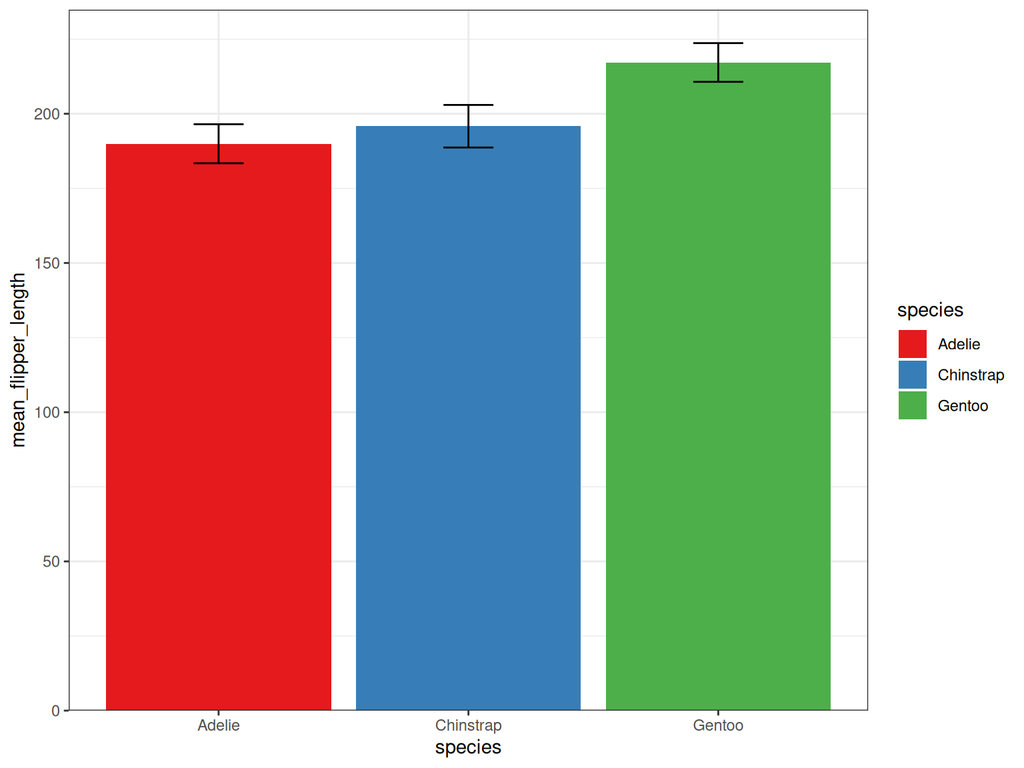

```r
penguins |>
  summarise(
    ## I chose an ugly column name to make sure the axis label
    ## was derived from the data
    mean_flipper_length = mean(flipper_length_mm, na.rm = TRUE),
    sd = sd(flipper_length_mm, na.rm = TRUE),
    .by = species
  ) |>
  ggplot(aes(species, mean_flipper_length, fill = species)) +
  geom_col() +
  geom_errorbar(
    aes(ymin = mean_flipper_length - sd, ymax = mean_flipper_length + sd),
    width = 0.2
  ) +
  ## Optionally set the colour palette
  scale_fill_brewer(palette = "Set1") +
  ## Optionally set the top of the y-axis to expand by 5% past the range
  ## whilst setting zero expansion at the bottom of the axis
  scale_y_continuous(expand = expansion(c(0, 0.05)))
```

### Challenge 2

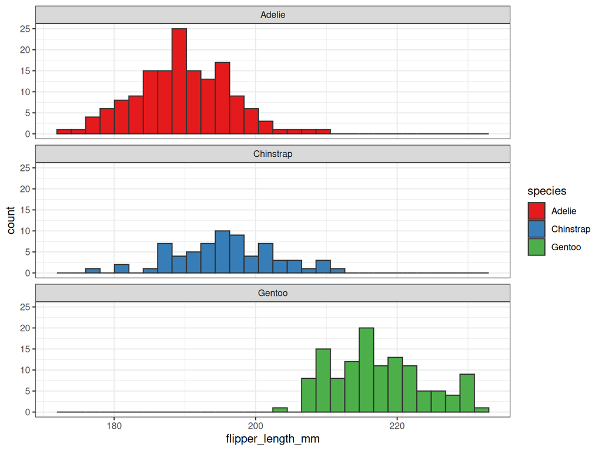

```r
penguins |>
  ggplot(aes(flipper_length_mm, fill = species)) +
  geom_histogram(colour = "grey20") +
  facet_wrap(~species, ncol = 1) +
  ## Optionally set the colour palette
  scale_fill_brewer(palette = "Set1")
```

### Challenge 3

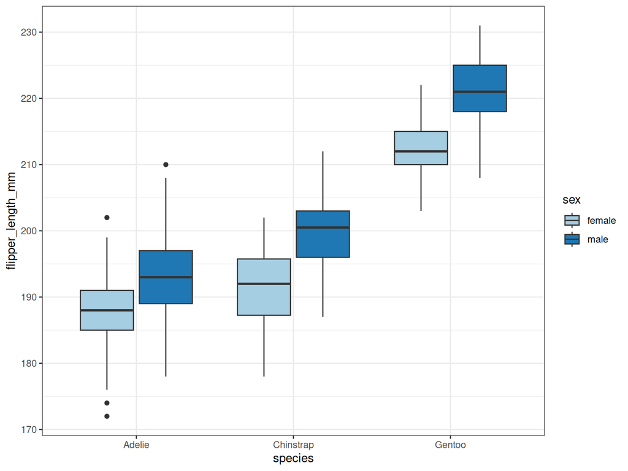

```r
penguins |>
  dplyr::filter(!is.na(sex)) |>
  ggplot(aes(species, flipper_length_mm, fill = sex)) +
  geom_boxplot() +
  ## An optional setting of the fill palette
  scale_fill_brewer(palette = "Paired")
```

### Challenge 4

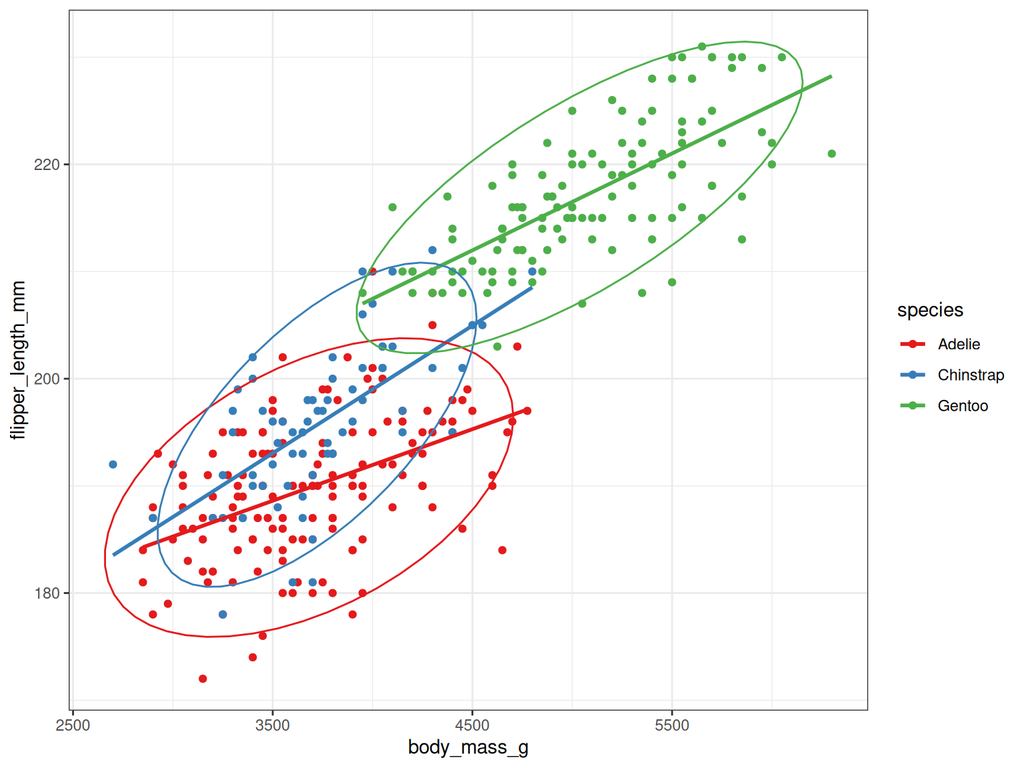

```r
penguins |>
  ggplot(aes(body_mass_g, flipper_length_mm, colour = species)) +
  geom_point() +
  stat_smooth(method = "lm", se = FALSE) +
  stat_ellipse()  +
  ## Optionally set the colour palette
  scale_colour_brewer(palette = "Set1")
```

## Extra Challenges

1. Load the Guinea Pigs dataset (`data/pigs.csv`)
   - Contains odontoblast (tooth) length in guinea pigs
   - Vitamin C via direct supplement or OJ
   - Three doses (Low, Med, High)
2. Create a boxplot of length separating groups by dose & supp
3. Find the mean odontoblast length for each dose & supplement method
4. Include the standard deviation alongside the mean
5. Create a barplot showing mean length with error bars

### Challenge 1

```r
pigs <- read_csv("data/pigs.csv") |>
  mutate(
    ## We didn't know how to do this at the time, but we do now
    supp = fct(supp),
    dose = fct(dose, levels = c("Low", "Med", "High"))
  )
glimpse(pigs)
```

```
Rows: 60
Columns: 3
$ len  <dbl> 4.2, 11.5, 7.3, 5.8, 6.4, 10.0, 11.2, 11.2, 5.2, 7.0, 16.5, 16.5,…
$ supp <fct> VC, VC, VC, VC, VC, VC, VC, VC, VC, VC, VC, VC, VC, VC, VC, VC, V…
$ dose <fct> Low, Low, Low, Low, Low, Low, Low, Low, Low, Low, Med, Med, Med, …
```

### Challenge 2

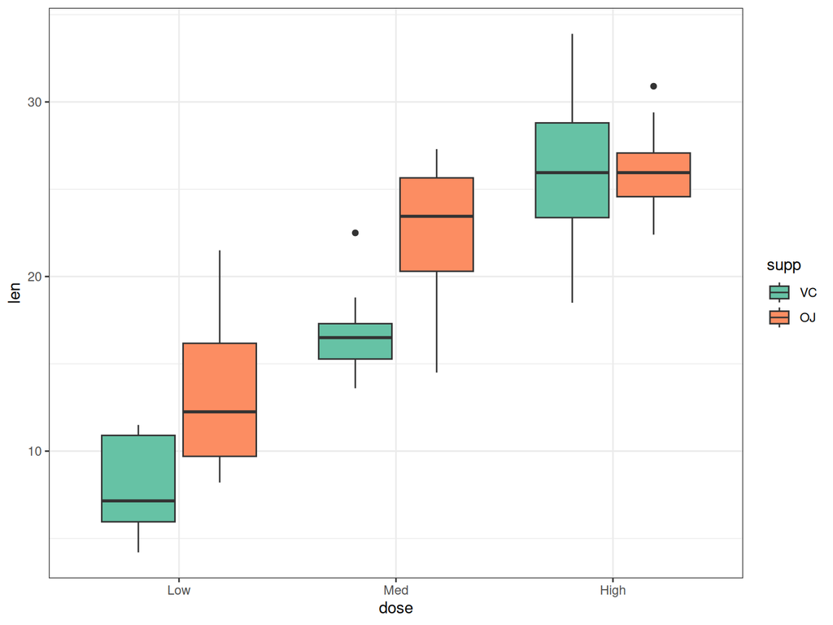

```r
pigs |>
  ggplot(aes(dose, len, fill = supp)) +
  geom_boxplot() +
  scale_fill_brewer(palette = "Set2")
```

### Challenges 3-5

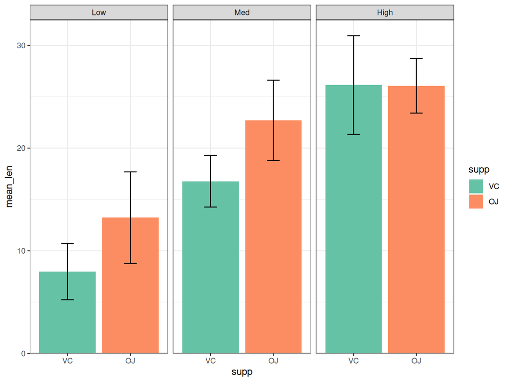

```r
pigs |>
  summarise(
    ## This step is challenge 3
    mean_len = mean(len),
    ## This step is challenge 4
    sd = sd(len),
    .by = c(supp, dose)
  ) |>
  ## Maing the plot is challenge 5
  ggplot(aes(supp, mean_len, fill = supp)) +
  geom_col() +
  geom_errorbar(
    aes(ymin = mean_len - sd, ymax = mean_len + sd),
    width = 0.2
  ) +
  facet_wrap(~dose) +
  scale_fill_brewer(palette = "Set2") +
  scale_y_continuous(expand = expansion(c(0, 0.05)))
```

### Additional Challenge

1. Find which sheets are in the file “data/NERP_Fauna_Survey_Protocols_Field_Trial_2015_Data_v1.xlsx” [^1]
2. Load the main data sheet from this file using `read_excel()` from `readxl`
3. How would you compare measurements for the species across different sites
   - Try using tables
   - How can you visualise this?

A few ideas are given below

```r
library(readxl)
library(ggrepel)
f <- "data/NERP_Fauna_Survey_Protocols_Field_Trial_2015_Data_v1.xlsx"
excel_sheets(f)
```

```
[1] "Instructions"       "Field Descriptions" "Codes used"
[4] "OUR DATA"           "OUR EFFORT"         "Pivot Species List"
[7] "Pivot Effort"
```

```r
nerp <- read_excel(f, sheet = "OUR DATA")
nerp |>
  summarise(
    n = n(), .by = c(`Common Name`, `Species Full`, `AusPlots Site No.`)
  ) |>
  dplyr::filter(!is.na(`AusPlots Site No.`)) |>
  pivot_wider(
    names_from = `AusPlots Site No.`, values_from = n, values_fill = 0
  )
```

```
# A tibble: 14 × 6
   `Common Name`          `Species Full` SASMDD012 SASMDD008 SASMDD017 SASMDD016
   <chr>                  <chr>              <int>     <int>     <int>     <int>
 1 Spotted Marsh Frog     Limnodynastes…        11        19         0         0
 2 Tessellated Gecko      Diplodactylus…         2         2         0         0
 3 House Mouse            Mus musculus           0         0         4         0
 4 Common Snake-eye       Morethia boul…         6        11         2         0
 5 Central Bearded Dragon Pogona vittic…         0         0         1         0
 6 Banjo Frog             Limnodynastes…         0         1         2         0
 7 Beaded Gecko           Lucasium dama…         0         0         1         0
 8 Yellow-faced Whipsnake Demansia psam…         0         3         0         0
 9 Speckled Wall Skink    Cryptoblephar…         1         0         0         0
10 Yellow-tailed Slider   Lerista                0         0         0         1
11 Yellow-tailed Slider   Lerista aeric…         0         0         1         8
12 Ctenophorus fordi      Ctenophorus f…         0         0         1         2
13 Desert Skink           Liopholis ino…         0         0         1         0
14 Sandplain Ctenotus     Ctenotus scho…         0         0         0         1
```

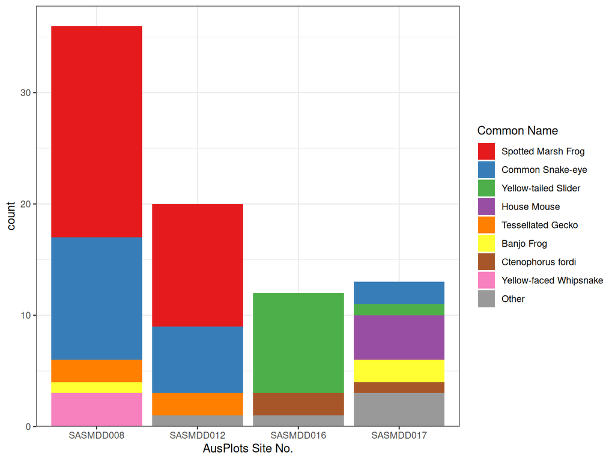

```r
nerp |>
  dplyr::filter(!is.na(`AusPlots Site No.`)) |>
  mutate(
    `Common Name` = fct_infreq(`Common Name`) |> fct_lump_min(min = 2)
  ) |>
  ggplot(aes(`AusPlots Site No.`, fill = `Common Name`)) +
  geom_bar() + # This will automatically tally any counts & create a stacked barplot
  scale_fill_brewer(palette = "Set1") +
  scale_y_continuous(expand = expansion(c(0, 0.05)))
```

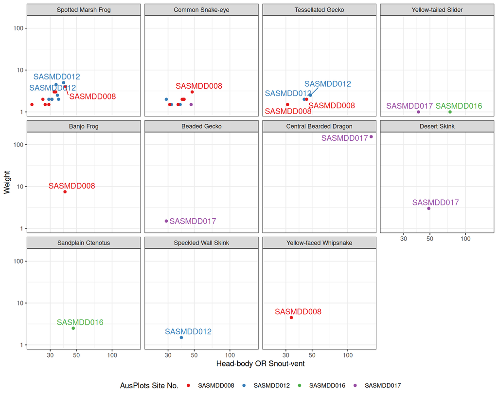

```r
nerp  |>
  dplyr::filter(
    !if_any(
      all_of(c("AusPlots Site No.", "Head-body OR Snout-vent", "Weight")),
      is.na
    )
  ) |>
  mutate(
    `Common Name` = fct_infreq(`Common Name`)
  ) |>
  ggplot(aes(`Head-body OR Snout-vent`, Weight, colour = `AusPlots Site No.`)) +
  geom_point() +
  geom_text_repel(
    aes(label = `AusPlots Site No.`), size = 4, show.legend = FALSE
  ) +
  facet_wrap(~`Common Name`) +
  scale_x_log10() +
  scale_y_log10() +
  scale_colour_brewer(palette = "Set1") +
  theme(legend.position = "bottom")
```

## Footnotes

[^1]: Obtained from https://portal.tern.org.au/results?topicTerm=surveillance